# Assignment 13: Metagenomics

# Metagenomics Assignment 13

This should be a .Rmd file. Include this file and the .html when you turn in the assignment.

**Student Name:** Ricardo Pineda **Student ID:** 917486212

Insert answers to exercises here.

Notes:  
1. Qiime was used to cluster 16S into OTUs  
2. match OTus against databast  
3. exported to R 4. (in class) Analyze results Working w/ dataset from root microbiomes from diff cultivars using Illumina seq.

```bash
# in input dir
#wget https://bis180ldata.s3.amazonaws.com/downloads/Metagenomics/MetaGenomeData.tar.gz

#tar -xvzf MetaGenomeData.tar.gz
```

**Exercise 1:** Using information in the RiceMappingFile.txt and RiceSeqs.fna answer the following questions.

(Connect cmds with pipes) 1. Find Headers in the fna  
- `grep ">" RiceSeqs.fna`  
2. Cut out only the bit you want  
- `cut -d " " -f 4`  
- cuts everything but `new_bc=` b/c 4th field of cut  
3. Sort the list of all the sequences w/ a specific barcode  
- `sort`  
4. Count the unique number of seqs  
- `uniq -c`  
5. sort again so you can see easily see the outliers  
- ‘sort’

all together (should be in the Data dir so you can refer to the riceseqs file) `grep ">" RiceSeqs.fna | cut -d " " -f 4 | sort | uniq -c | sort`

**a** Are the number of sequences for each sample approximately the same or are there any outliers? If so, which samples do they belong to?

Most were around the 500-2000 sequence range while some were significantly higher or lower than the rest. Some of the outliers with significantly higher and lower numbers of sequences were:

- ACGGTGAGTGTCGT w/ 4880 sequences which is the barcode from IM2
- ACCGCAGAGTCAGT w/ 3870 sequences which is the barcode from IM1
- ACAGACCACTCAGT w/ 3092 sequences which is the barcode from NLM2
- AACGCACGCTAGGT w/ 2965 sequences which is the barcode from NEM1
- AGCAGTCGCGATGT w/ 289 sequences which is the barcode from IE1

```bash
#For the one with 4880 Samples
#grep "ACGGTGAGTGTCGT" RiceMappingFile.txt
#For the one with 3870 Samples
#grep "ACCGCAGAGTCAGT" RiceMappingFile.txt
#For the one with 3092 Samples
#grep "ACAGACCACTCAGT" RiceMappingFile.txt
#For the one with 2965 Samples
#grep "AACGCACGCTAGGT" RiceMappingFile.txt
#For the one with 289 Samples
#grep "AGCAGTCGCGATGT" RiceMappingFile.txt
```

**b** Could a different number of sequences per sample affect future analysis? Explain your reasoning.

Yes. This is because we are going to be going to be looking at diversity of samples and the number of sequences associated with a specific sample in what we’re studying.

**Exercise 2:**

```bash
#In input dir.
#Outbut from running Qiime to cluster and classify our OTU
#wget http://bis180ldata.s3.amazonaws.com/downloads/Metagenomics/qiime_export.tar.gz
#tar -xvzf qiime_export.tar.gz
```

From the OTU summary, look at how many OTUs correspond to each sample (“counts/sample detail”). Do technical replicates agree with one another? At this stage, what conclusions can you draw about the number of OTUs in these samples?

They do not agree with each other completely. The technical replicates are generally close to each other but there is still quite a bit of difference. I can probably conclude that there are more actual OTUs than the measured OTUs in the samples.

**Exercise 3:**

```r
#install phyloseq

#if (!requireNamespace("BiocManager", quietly = TRUE))
#    install.packages("BiocManager")

#BiocManager::install("phyloseq")

#update none when asked, (It takes a while)
```

```r
library(phyloseq)
library(tidyverse)
#Import OTU count table into R
otu <- read.delim("../input/qiime_export/otu_table.txt", skip=1, row.names = 1, as.is = TRUE) %>% as.matrix()
head(otu)
```

```
##                                          MB1 IM2 MM2 MB2 NEB1 IB2 NEM2 IM1 MM1
## 0f2f4b8891b1f24c8bb5698ec6fe921358d55600  81 191  24 104   26 134   27 129  43
## a3b11f106460edc243c2d14554a6049e652eec74  15  20   4  20   68  12   22  11   1
## 4eddcd305ad04b61c27b8dd5fc0d7f98d49a7f96   3   1   0   5    8   8    0  11   1
## 0cb94adb2dd5ba6120e2683fcb3040f4add50515   3   0   0   5   78   0   16   1   0
## d6c75183a76efa661e639b801173fbc35bdd89f3  19  49   4  26   55  28   28  67  15
## 73cd3a1979ce8d2c4442b343156eaba7dd77961c   5  27   0   2    4  24    7  21   9
##                                          NEM1 NLB1 IB1 NLB2 NEE2 NLM2 IE2 NLM1
## 0f2f4b8891b1f24c8bb5698ec6fe921358d55600   57   30  83   43    9   62   2   15
## a3b11f106460edc243c2d14554a6049e652eec74   21   12   6   19   75   11   4    5
## 4eddcd305ad04b61c27b8dd5fc0d7f98d49a7f96    2    2   3    2   23    1  48    2
## 0cb94adb2dd5ba6120e2683fcb3040f4add50515   19   10   3    4  112    1   0    1
## d6c75183a76efa661e639b801173fbc35bdd89f3   46   38  23   39  118   34  34   15
## 73cd3a1979ce8d2c4442b343156eaba7dd77961c   23   29  70   72    2   75   1   17
##                                          NLE2 IE1 NEB2 NLE1 ME2 ME1 NEE1
## 0f2f4b8891b1f24c8bb5698ec6fe921358d55600    7   6   45    3   8   3    5
## a3b11f106460edc243c2d14554a6049e652eec74   27   1   85   21   8   4   89
## 4eddcd305ad04b61c27b8dd5fc0d7f98d49a7f96   27  15    4   21  34  31   47
## 0cb94adb2dd5ba6120e2683fcb3040f4add50515    6   1   54   11   1   2  183
## d6c75183a76efa661e639b801173fbc35bdd89f3   62  12   32   59  29  25  141
## 73cd3a1979ce8d2c4442b343156eaba7dd77961c    3   3    5    0   0   0    0
```

```r
#import taxonomy key
tax <- read.delim("../input/qiime_export/taxonomy.tsv", as.is = TRUE) %>%
  select(-Consensus) %>%
  mutate(Taxon = str_remove_all(Taxon, ".__| ")) %>%
  separate(Taxon, into = c("domain", "phylum", "class", "order", "family", "genus", "species"), sep = ";", fill="right")
rownames(tax) <- tax$Feature.ID
tax <- tax %>% select(-Feature.ID) %>% as.matrix()
tax[tax==""] <- NA
head(tax)
```

```
##                                          domain     phylum
## 000367dd69463ae78b69a5b3d37d0dfcf90e7db5 "Bacteria" "Gemmatimonadota"
## 0004b5f7d8eccd90801de58cfaeb7845b8683ab9 "Bacteria" "Desulfobacterota"
## 00056d57de82999f8734046bb073ea9216b89873 "Bacteria" "Actinobacteriota"
## 00080c49842cbd276e7b213d6f6607fd4d15065f "Bacteria" "Firmicutes"
## 000dd36345f500996864dfbb7f412632c2347130 "Bacteria" "Acidobacteriota"
## 0011beb5ee8cb2c4d4b627b39c5d08cecbeb70e1 "Bacteria" "Gemmatimonadota"
##                                          class
## 000367dd69463ae78b69a5b3d37d0dfcf90e7db5 "Gemmatimonadetes"
## 0004b5f7d8eccd90801de58cfaeb7845b8683ab9 "Desulfuromonadia"
## 00056d57de82999f8734046bb073ea9216b89873 "Thermoleophilia"
## 00080c49842cbd276e7b213d6f6607fd4d15065f "Bacilli"
## 000dd36345f500996864dfbb7f412632c2347130 "Holophagae"
## 0011beb5ee8cb2c4d4b627b39c5d08cecbeb70e1 "S0134_terrestrial_group"
##                                          order
## 000367dd69463ae78b69a5b3d37d0dfcf90e7db5 "Gemmatimonadales"
## 0004b5f7d8eccd90801de58cfaeb7845b8683ab9 "Desulfuromonadia"
## 00056d57de82999f8734046bb073ea9216b89873 "Gaiellales"
## 00080c49842cbd276e7b213d6f6607fd4d15065f "Lactobacillales"
## 000dd36345f500996864dfbb7f412632c2347130 "Holophagales"
## 0011beb5ee8cb2c4d4b627b39c5d08cecbeb70e1 "S0134_terrestrial_group"
##                                          family
## 000367dd69463ae78b69a5b3d37d0dfcf90e7db5 "Gemmatimonadaceae"
## 0004b5f7d8eccd90801de58cfaeb7845b8683ab9 "Geothermobacteraceae"
## 00056d57de82999f8734046bb073ea9216b89873 "uncultured"
## 00080c49842cbd276e7b213d6f6607fd4d15065f "Streptococcaceae"
## 000dd36345f500996864dfbb7f412632c2347130 "Holophagaceae"
## 0011beb5ee8cb2c4d4b627b39c5d08cecbeb70e1 "S0134_terrestrial_group"
##                                          genus
## 000367dd69463ae78b69a5b3d37d0dfcf90e7db5 "uncultured"
## 0004b5f7d8eccd90801de58cfaeb7845b8683ab9 "Geothermobacter"
## 00056d57de82999f8734046bb073ea9216b89873 "uncultured"
## 00080c49842cbd276e7b213d6f6607fd4d15065f "Streptococcus"
## 000dd36345f500996864dfbb7f412632c2347130 "uncultured"
## 0011beb5ee8cb2c4d4b627b39c5d08cecbeb70e1 "S0134_terrestrial_group"
##                                          species
## 000367dd69463ae78b69a5b3d37d0dfcf90e7db5 "uncultured_bacterium"
## 0004b5f7d8eccd90801de58cfaeb7845b8683ab9 NA
## 00056d57de82999f8734046bb073ea9216b89873 "uncultured_bacterium"
## 00080c49842cbd276e7b213d6f6607fd4d15065f "uncultured_bacterium"
## 000dd36345f500996864dfbb7f412632c2347130 NA
## 0011beb5ee8cb2c4d4b627b39c5d08cecbeb70e1 "uncultured_bacterium"
```

```r
#Create a df of sample information
sampleinfo <- data.frame(sample=colnames(otu)) %>%
  mutate(cultivar=str_sub(sample,1,1),
         cultivar={str_replace(cultivar, "M", "M104") %>%
             str_replace( "I", "IR50") %>%
             str_replace( "N", "Nipponbare")},
         time={str_extract(sample,"N(E|L)") %>%
             str_remove("N")},
         location={str_extract(sample,".[12]") %>% str_sub(1,1)},
         location={str_replace(location, "B", "rhizoplane") %>%
             str_replace("M", "rhizosphere") %>%
             str_replace("E", "endosphere")})
rownames(sampleinfo) <- sampleinfo$sample
sampleinfo <- sampleinfo %>% select(-sample)
head(sampleinfo)
```

|  | cultivar | time | location |
| --- | --- | --- | --- |
| MB1 | M104 | NA | rhizoplane |
| IM2 | IR50 | NA | rhizosphere |
| MM2 | M104 | NA | rhizosphere |
| MB2 | M104 | NA | rhizoplane |
| NEB1 | Nipponbare | E | rhizoplane |
| IB2 | IR50 | NA | rhizoplane |

```r
#Bring OTU and taxonomy table into phyloseq obj
rice.ps <- phyloseq(otu_table(otu,taxa_are_rows=TRUE), tax_table(tax), sample_data(sampleinfo))
rice.ps
```

```
## phyloseq-class experiment-level object
## otu_table()   OTU Table:         [ 11151 taxa and 24 samples ]
## sample_data() Sample Data:       [ 24 samples by 3 sample variables ]
## tax_table()   Taxonomy Table:    [ 11151 taxa by 7 taxonomic ranks ]
```

```r
#filter and rm rare seq
rice.ps.small <- filter_taxa(rice.ps, function(x) sum(x > 5) > 2, prune=TRUE) #require greater than five observation in more than two samples
rice.ps.small <- prune_taxa(complete.cases(tax_table(rice.ps.small)[,"phylum"]),  rice.ps.small) #remove taxa from unknown phylum
rice.ps.small
```

```
## phyloseq-class experiment-level object
## otu_table()   OTU Table:         [ 104 taxa and 24 samples ]
## sample_data() Sample Data:       [ 24 samples by 3 sample variables ]
## tax_table()   Taxonomy Table:    [ 104 taxa by 7 taxonomic ranks ]
```

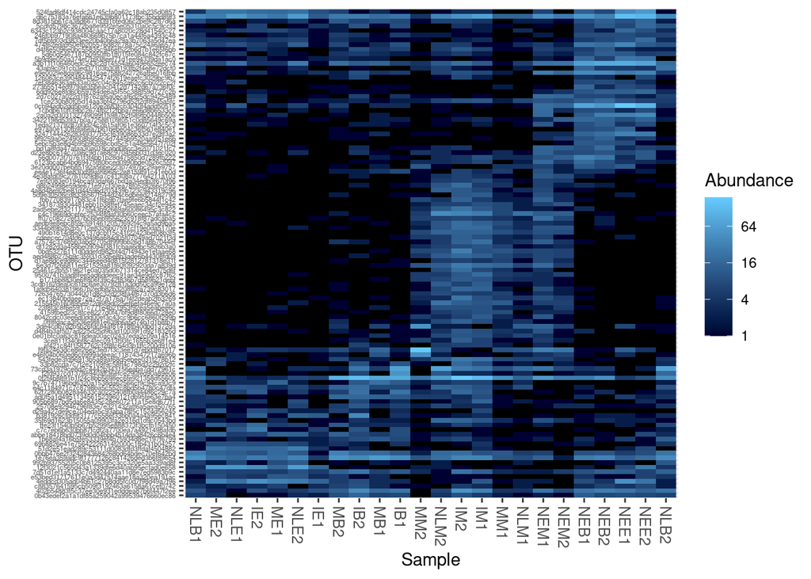

```r
#create a heatmap of OTUs/sample
#Row = OTU
#Column = sample
# hi RA = brighter color
#Clustering via B-C dissimilarity
plot_heatmap(rice.ps.small)
```

Although, the resolution of the y-axis makes it difficult to read each OTU, it is still a valuable preliminary visualization. What types of information can you gain from this heat map? Are there any trends present at this stage with respect to the various samples?

- I can thell that some OTUs are common in only a few samples while there are some chunks of OTUs primarily see in only a few samples. Examples of this is the top right and the middle chunks of similar OTUs.

**Exercise 4:**

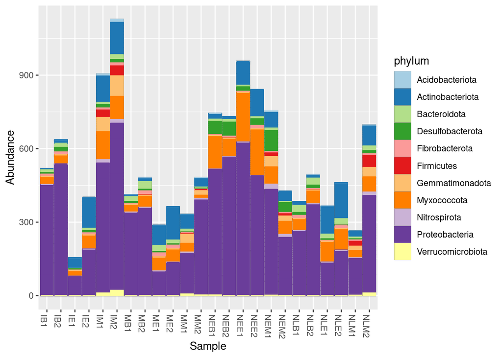

```r
#making a boxplot each sample w/ absolute abundance of OTUs and the phylum that they belong to w/i each sample
#plot_bar(rice.ps.small, fill="phylum")
#Cleaning the plot so taht there is no longer black lines separating each of the colored bits w/i each sample.
pl <- plot_bar(rice.ps.small, fill="phylum")
pl + geom_col(aes(fill=phylum, color=phylum)) +
  scale_fill_brewer(type="qual", palette="Paired") + # better colors
  scale_color_brewer(type="qual", palette="Paired") # better colors
```

```r
rice.ps.small %>%
  psmelt() %>%
  group_by(phylum) %>%
  summarize(Abundance=sum(Abundance)) %>%
  arrange(desc(Abundance))
```

| phylum | Abundance |
| --- | --- |
| Proteobacteria | 8326 |
| Myxococcota | 1684 |
| Actinobacteriota | 1494 |
| Desulfobacterota | 406 |
| Bacteroidota | 350 |
| Gemmatimonadota | 334 |
| Firmicutes | 209 |
| Fibrobacterota | 197 |
| Nitrospirota | 110 |
| Verrucomicrobiota | 62 |

[output cut: 1 more lines]

**a.** Make a bar plot with samples grouped by location.

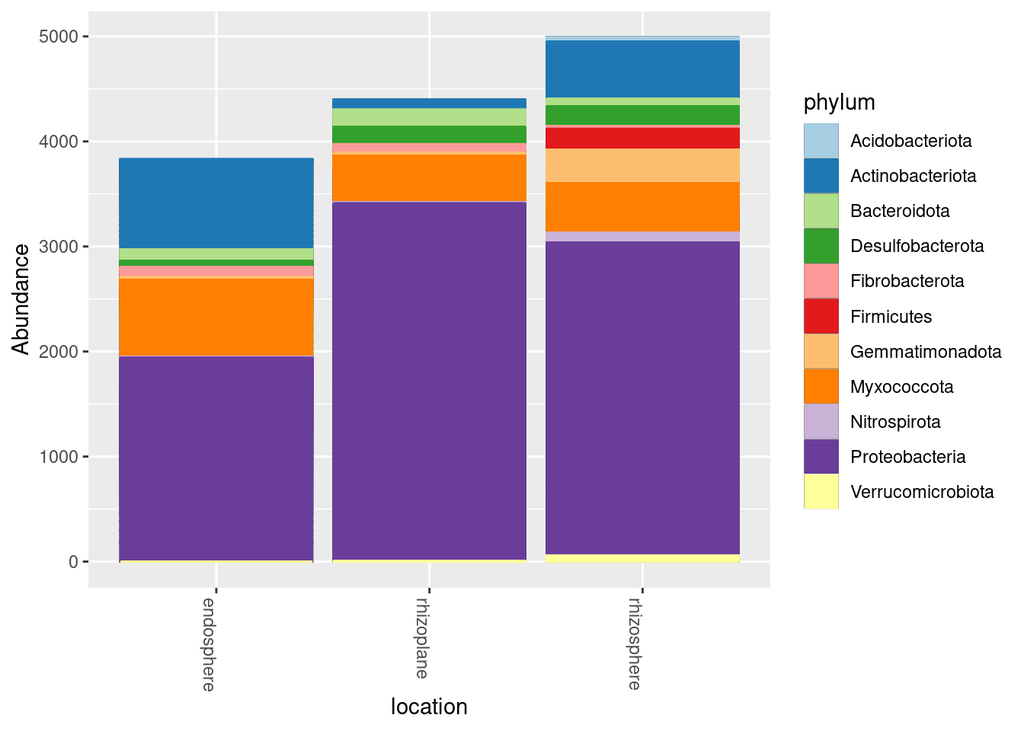

```r
pl <- plot_bar(rice.ps.small, x = "location", fill="phylum")
pl + geom_col(aes(fill=phylum, color=phylum)) +
  scale_fill_brewer(type="qual", palette="Paired") + # better colors
  scale_color_brewer(type="qual", palette="Paired") # better colors
```

**b.** Make a table showing the phylum abundance by location (build on code above). I’ve shown what the first two rows should look like; yours should have 11 rows.

```r
rice.ps.small %>%
  psmelt() %>%
  group_by(location, phylum) %>%
  summarize(Abundance=sum(Abundance)) %>%
  pivot_wider(names_from = "location", values_from = "Abundance")
```

| phylum | endosphere | rhizoplane | rhizosphere |
| --- | --- | --- | --- |
| Acidobacteriota | 2 | 1 | 44 |
| Actinobacteriota | 857 | 94 | 543 |
| Bacteroidota | 109 | 168 | 73 |
| Desulfobacterota | 60 | 160 | 186 |
| Fibrobacterota | 96 | 81 | 20 |
| Firmicutes | 0 | 5 | 204 |
| Gemmatimonadota | 2 | 11 | 321 |
| Myxococcota | 758 | 458 | 468 |
| Nitrospirota | 5 | 8 | 97 |
| Proteobacteria | 1942 | 3408 | 2976 |

[output cut: 1 more lines]

**c.** When comparing by location, which single phylum is most abundant across all locations? Are there any predominant phyla greatly enriched (greater than 10-fold) in one location compared to the others?

Proteobacteria are abundant across the different locations. Acidobacteria, firmicutes, gemmatimonadata, Nitrospirota, and Verrucomicrobiota are enriched in the rhizosphere.

**d.** Repeat **a, b, and c** but this time grouping by cultivar. When comparing by cultivar, is the predominant phyla consistent with that observed in Part B? Are there any predominant phyla unique to a specific cultivar? What does this indicate to you about the effect of the genotype and/or the effect of the sample location?

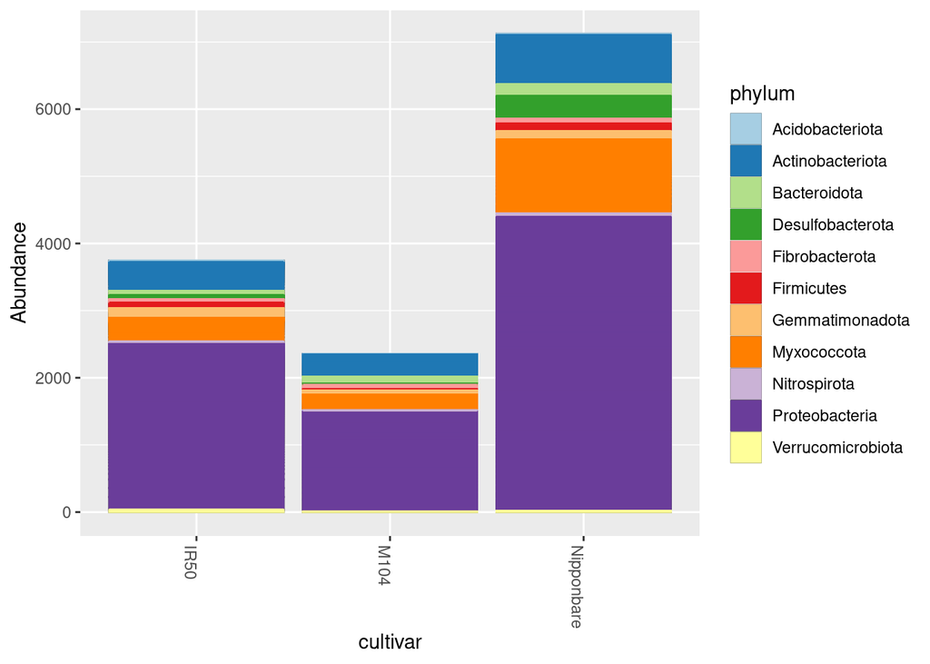

```r
#A repeat
pl <- plot_bar(rice.ps.small, x = "cultivar", fill="phylum")
pl + geom_col(aes(fill=phylum, color=phylum)) +
  scale_fill_brewer(type="qual", palette="Paired") + # better colors
  scale_color_brewer(type="qual", palette="Paired") # better colors
```

```r
#B repeat
rice.ps.small %>%
  psmelt() %>%
  group_by(cultivar, phylum) %>%
  summarize(Abundance=sum(Abundance)) %>%
  pivot_wider(names_from = "cultivar", values_from = "Abundance")
```

| phylum | IR50 | M104 | Nipponbare |
| --- | --- | --- | --- |
| Acidobacteriota | 23 | 8 | 16 |
| Actinobacteriota | 427 | 332 | 735 |
| Bacteroidota | 68 | 106 | 176 |
| Desulfobacterota | 57 | 13 | 336 |
| Fibrobacterota | 52 | 71 | 74 |
| Firmicutes | 80 | 15 | 114 |
| Gemmatimonadota | 145 | 64 | 125 |
| Myxococcota | 356 | 232 | 1096 |
| Nitrospirota | 32 | 20 | 58 |
| Proteobacteria | 2471 | 1485 | 4370 |

[output cut: 1 more lines]

C repeat:

None of the phyla are significantly enriched for a specific cultivar. This suggests that location had much more of an effect on phyla diversity in comparison to genotype.

**Exercise 5:**

a-div tells us species diversity richness (#taxa w/i a sample)

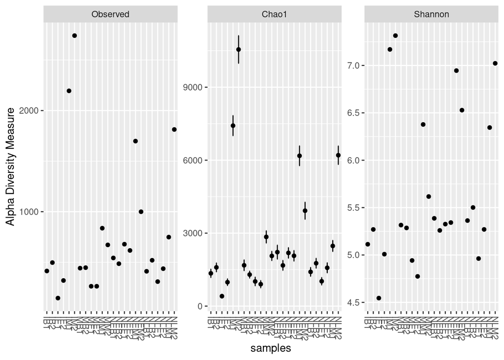

```r
#Plot richness
plot_richness(rice.ps, measures=c("Observed", "Chao1", "Shannon"))
```

Is there an alpha diversity metric that estimates the sample diversity differently than the other metrics? If so, which one is it? (This is not a question about the scale of the y-axis, but the patterns of which samples show relatively high and low diversity).

Observed and Chao1 have roughly the same patterns of sample diversity with many relative low alpha diversity and a couple higher diversity samples. The Shannon on the other hand differentiates more between low alpha diversity and intermediate alpha diversity.

**Exercise 6:**  
Look at the help file for `plot_richness` and plot the samples grouped first by cultivar and then make a separate plot with them grouped by location. Do either of these categories seem to affect species diversity? Thinking back to the difference in read counts per sample, could the differences in diversity just be due to differences in sequencing depth?

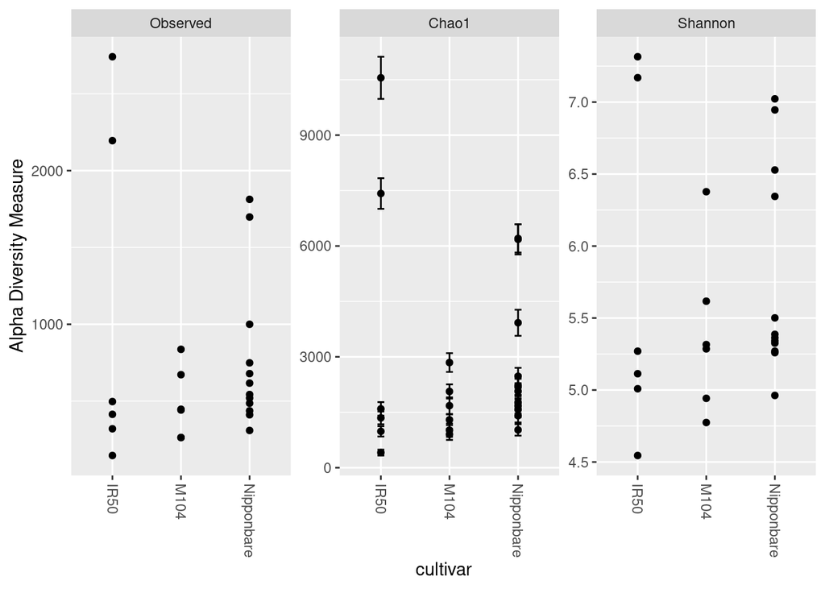

```r
plot_richness(rice.ps, "cultivar", measures=c("Observed", "Chao1", "Shannon"))
```

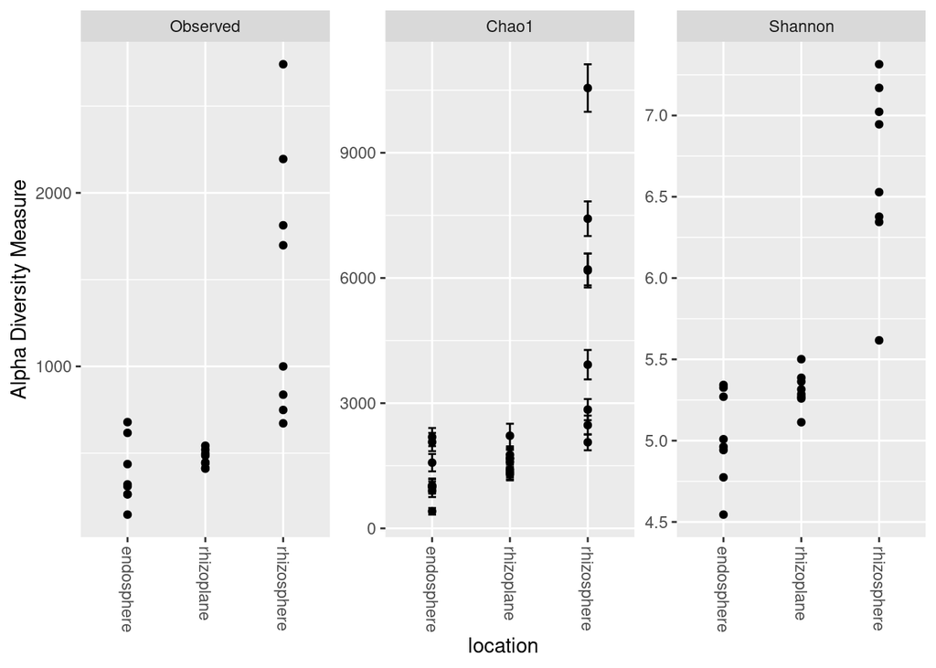

```r
plot_richness(rice.ps, "location", measures=c("Observed", "Chao1", "Shannon"))
```

Yes, the categories do seem to affect species diversity. Going back to question 4, the plot with location all had roughly the same number of reads while the plot with cultivar had significantly different numbers of reads per sample. So the differences in diversity could be due to sequencing depth.

**Exercise 7:**

```r
#Visualizing the diversity b/w samples (b-div)

#Compute b-c dissimilarity distances and MDS coords
rice.ord.small <- ordinate(rice.ps.small, method="NMDS", distance="bray")
```

```
## Square root transformation
## Wisconsin double standardization
## *** Best solution repeated 2 times
```

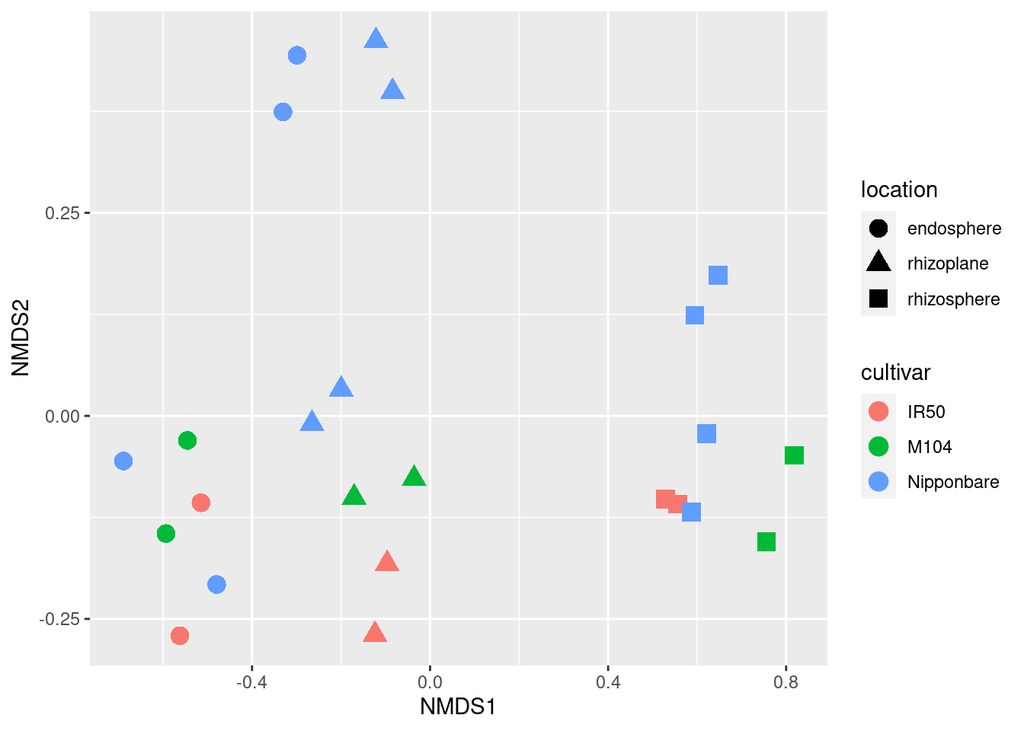

```r
#Plot
pl <- plot_ordination(rice.ps, rice.ord.small, type="samples", color="cultivar", shape="location")
pl + geom_point(size=4)
```

**a.** Does cultivar or location appear to have more of an influence on the clustering?

Location

**b.** Which two locations are more similar to one another? Does that make biological sense?

**Exercise 8:**  
Four Nipponbarre samples form a distinct group separated from all other samples. Replot the data (changing the plot aesthetics) to provide an explanation.

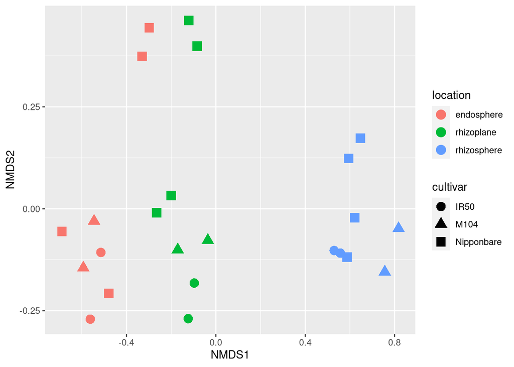

```r
pl <- plot_ordination(rice.ps, rice.ord.small, type="cultivar", color="location", shape="cultivar")
pl + geom_point(size=4)
```

They are from the same cultivar.